# Explanability: A contrastive Study of a Decision Tree versus a BiLstm:

## Table of Contents:

- Explainability
- Dataset
- Decision Tree
- BiLSTM
- Application

```python
import numpy as np
import pandas as pd
from sklearn.preprocessing import LabelEncoder
from sklearn.feature_extraction.text import TfidfVectorizer
from datetime import datetime
from sklearn.model_selection import train_test_split
from sklearn.naive_bayes import MultinomialNB
from sklearn.linear_model import LogisticRegression


# Read in the train, test data
X_read = pd.read_csv('train_data_fix.csv')
y_read = pd.read_csv('train_results.csv')
X_test_read = pd.read_csv('test_data_fix.csv')

# Narrow the dataset down to the "text" or "target" columns.
X = X_read['text'].copy()
y = y_read['target'].copy()
X_test = X_test_read['text'].copy()


# High-level look at the dataset:
print(f'dataset sizes:')
print(f'X shape: {X.shape}')
print(f'y shape: {y.shape}')
print(f'X_test shape: {X_test.shape}')
print(f'\ncomposition and distribution of y:')
print(f'y.value counts:\n {y.value_counts(normalize=True)}')


# The target data are almost evenly split between positive and negative, with barely any neutral.

# # Preprocessing

# #### Encode the target values as numbers



le = LabelEncoder()
le.fit(y.unique())
y = le.transform(y) #positive:2, negative:0, neutral:1
y[:5]


# #### Remove punctuation and numbers


def strip_punctuation(text):
    """
    Removes punctuation, digits, single characters and internet-stuff (url, html tags) from a string.
    """
    import re
    import string
    text = re.compile('[%s]' % re.escape(string.punctuation)).sub(' ', text)  # remove most punctuation
#     text = text.translate(str.maketrans('','', string.punctuation)) # backup remove most punctuation
    text = text.translate(str.maketrans('', '', string.digits)) # remove digits
    text = re.sub(r'https?://\S+|www\.\S+', '', text) # Removes url
    text = re.compile(r'<[^>]+>').sub('', text) #Removes HTML tags:
    text = re.sub(r'\b\w{1}\b', '', text) #re.sub(r"\s+[a-zA-Z]\s+", ' ', text) # Single character removal
    text = re.sub(r'\s+', ' ', text) # Remove multiple spaces
    return text



# Preprocess both train and test data
X = X.apply(lambda x: strip_punctuation(x))
X_test = X_test.apply(lambda x: strip_punctuation(x))
X


# #### Stem


def stem_text(text, stemmer):
    stemmed_text = ''

    if stemmer == 'porter':
        from nltk.stem import PorterStemmer
        st = PorterStemmer()
    elif stemmer == 'snowball':
        from nltk.stem import SnowballStemmer
        st = SnowballStemmer('english')

    for word in text.split(' '):
        stemmed_text += st.stem(word) + " "

    return stemmed_text[:-1]


# Stem data with snowball stemmer
X = X.apply(lambda x: stem_text(x, 'snowball'))
X_test = X_test.apply(lambda x: stem_text(x, 'snowball'))
X


# #### TFIDF Vectorizer


# Vectorize test data
tfvectorizer = TfidfVectorizer(min_df = 1e-6, ngram_range = (1,5), stop_words = None,
                            lowercase =  True, use_idf= True, sublinear_tf = True)



# Train the vectorizer on the training data and transform the training data and the test data
X_bag = tfvectorizer.fit_transform(X)
print(f'X_bag.shape: {X_bag.shape}')
X_test_bag = tfvectorizer.transform(X_test)


# Train test split the word bag
X_train, X_val, y_train, y_val = train_test_split(X_bag,y, train_size = 0.7, random_state=42)
#See what the resulting size of the train test split is
print(f'X_train shape: {X_train.shape}')
```

```
dataset sizes:
X shape: (1040323,)
y shape: (1040323,)
X_test shape: (560175,)

composition and distribution of y:
y.value counts:
 positive    0.500264
negative    0.499655
neutral     0.000081
Name: target, dtype: float64
X_bag.shape: (1040323, 2347985)
X_train shape: (728226, 2347985)
```

```python
from sklearn.tree import DecisionTreeClassifier
import time
start_time = time.time()
clf_decision_tfidf = DecisionTreeClassifier(random_state=2)
clf_decision_tfidf.fit(X_train[0:200000], y_train[0:200000])
print("Time to taken to fit the TF-IDF as input for classifier: " + str(time.time() - start_time))
```

```
Time to taken to fit the TF-IDF as input for classifier: 3934.720956325531
```

```python
from sklearn import metrics
y_pred=clf_decision_tfidf.predict(X_val)
print(y_pred)
#rbf.score(X_val, y_val)
print("Accuracy:",metrics.accuracy_score(y_val, y_pred))
```

```
[2 2 0 ... 2 0 2]
Accuracy: 0.7092858950903085
```

```python
y_out=clf_decision_tfidf.predict(X_test_bag)
```

```python
y_out.shape
```

```
(560175,)
```

# Explainability

Blackbox model versus WhiteBlox Model Comparing BLSTM + Decision Trees

```python
from sklearn.ensemble import RandomForestClassifier
rbf = RandomForestClassifier(n_estimators=1)
rbf.fit(X_train[0:100], y_train[0:100])
```

[output not shown]

```python
RF_clf = RandomForestClassifier(
    criterion="gini", max_depth=200, n_estimators=100
)  # initialise your random forest classifier
RF_clf.fit(X_train, y_train)
```

```python
from sklearn import metrics
# Model Accuracy, how often is the classifier correct?
y_pred=rbf.predict(X_val)
print(y_pred)
#rbf.score(X_val, y_val)
print("Accuracy:",metrics.accuracy_score(y_val, y_pred))
```

[output not shown]

```python
count = 0
with open('_without_ft_fit_transfomm_just_predict__random_svm_000_data.csv', 'a') as f:
    if count == 0:
        f.write("id,target\n")
    for value in y_out:
        #print(value)
        #break
        f.write("{},{}\n".format(int(count), value))
        count = count + 1
```

```python
from sklearn import svm
y_train.shape
from sklearn.metrics import accuracy_score
SVM = svm.SVC(C=1.0, kernel='linear', degree=3, gamma='auto')
SVM.fit(X_train,y_train)
```

# Explainability

As we have learned in class, Machine Learning involves a series of tradeoffs. Explanability means that given input x and ouput y, you can explain how your model came to that deciding "y". In our competition, given a tweet, we can explain why the model took the decision to classify it as "positive", "negative" or "neutral". In Machine Learning, we have blackbox and whitebox models. Blackbox models are those that may not be easily interpreted. *Why* the model classified an input may be unclear to the user. White box models often use simplier techniques.

In our exploration of this problem, we used white-box ("explainable*) and blackbox models.

Our blackbox models were: (1) BiLSTM (2) Neural Network

Our whitebox models were: (1) SVM (2) Decision Tree

We will constrast our BiLSTM with our decision tree.

```python
import pandas as pd
import matplotlib.pyplot as plt
from wordcloud import WordCloud
```

```python
X_read = pd.read_csv('train_data_fix.csv')
y_read = pd.read_csv('train_results.csv')
X_test_read = pd.read_csv('test_data_fix.csv')

# Narrow the dataset down to the "text" or "target" columns.
X = X_read['text'].copy()
y = y_read['target'].copy()
X_test = X_test_read['text'].copy()

X = X.apply(lambda x: strip_punctuation(x))
X_test = X_test.apply(lambda x: strip_punctuation(x))
X
def stem_text(text, stemmer):
    stemmed_text = ''

    if stemmer == 'porter':
        from nltk.stem import PorterStemmer
        st = PorterStemmer()
    elif stemmer == 'snowball':
        from nltk.stem import SnowballStemmer
        st = SnowballStemmer('english')

    for word in text.split(' '):
        stemmed_text += st.stem(word) + " "

    return stemmed_text[:-1]


# Stem data with snowball stemmer
X = X.apply(lambda x: stem_text(x, 'snowball'))
X_test = X_test.apply(lambda x: stem_text(x, 'snowball'))
```

```python
import os
print (os.path.exists("tokens.txt"))
file = open("tokens.txt", "r")
file_lines = file.readlines()
print(y[2])
count = 0
positive_list = ""
negative_list = ""
neutral_list = ""
for line in file_lines:
    if 'day' not in line:
        if y[count] == 'positive':
            positive_list = positive_list + line
        if y[count] == 'negative':
            negative_list = negative_list + line
        if y[count] == 'neutral':
            neutral_list = neutral_list + line
    count = count + 1
    #if count == 300000:
     #   break
```

```
True
positive
```

# Understanding our Data

As our model will learn on the most frequent terms of each class, it helps to visualize them below. We can see in these word clouds there are some words that have a distinct meaning on their own.

For positive: "Good, love, thank, great" may have a strong influence on their own. There are cases where it may be best to process these in n-grams such as "time" or work.

```python
# Positive
```

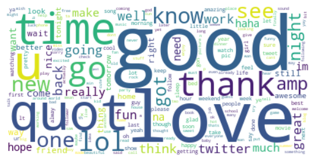

```python
word_cloud = WordCloud(collocations = False, background_color = 'white').generate(positive_list)
plt.imshow(word_cloud, interpolation='bilinear')
plt.axis("off")
plt.show()
```

```python
# Negative
```

[figure not shown]

```python
word_cloud = WordCloud(collocations = False, background_color = 'white').generate(negative_list)
plt.imshow(word_cloud, interpolation='bilinear')
plt.axis("off")
plt.show()
```

```python
# Neutral
```

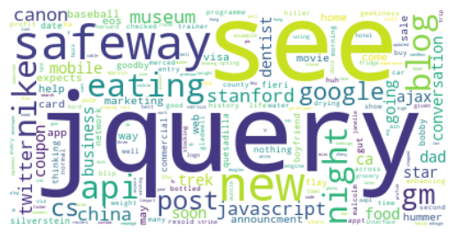

```python
word_cloud = WordCloud(collocations = False, background_color = 'white').generate(neutral_list)
plt.imshow(word_cloud, interpolation='bilinear')
plt.axis("off")
plt.show()
```

# Decision Tree in Action:

Decision trees are supervised methods, so they need to be trained on some annotated data. Thus the general idea is the same as for any text classification: given a set of documents (for instance represented as TFIDF vectors) together with their labels, the algorithm will calculate which how much each word correlates with a particular label.

For instance it might find that the word "excellent" often appears in documents labeled as positive, whereas the word "terrible" mostly appears in negative documents. By combining all such observations it builds a model able to assign a label to any document. If we visualize our trained model, we can inteprete where it made a decision -> based on the significance of the word.

```python
from sklearn import tree
y_pred[0]
text_representation = tree.export_text(clf_decision_tfidf)
print(text_representation)
```

```
|--- feature_1788918 <= 0.04
|   |--- feature_1586680 <= 0.02
|   |   |--- feature_1196283 <= 0.04
|   |   |   |--- feature_2298485 <= 0.04
|   |   |   |   |--- feature_1118931 <= 0.06
|   |   |   |   |   |--- feature_1329373 <= 0.03
|   |   |   |   |   |   |--- feature_680339 <= 0.05
|   |   |   |   |   |   |   |--- feature_1315838 <= 0.04
|   |   |   |   |   |   |   |   |--- feature_2229264 <= 0.04
|   |   |   |   |   |   |   |   |   |--- feature_748061 <= 0.02
|   |   |   |   |   |   |   |   |   |   |--- feature_2126182 <= 0.04
|   |   |   |   |   |   |   |   |   |   |   |--- truncated branch of depth 2484
|   |   |   |   |   |   |   |   |   |   |--- feature_2126182 >  0.04
|   |   |   |   |   |   |   |   |   |   |   |--- truncated branch of depth 221
|   |   |   |   |   |   |   |   |   |--- feature_748061 >  0.02
|   |   |   |   |   |   |   |   |   |   |--- feature_277084 <= 0.05
|   |   |   |   |   |   |   |   |   |   |   |--- truncated branch of depth 97
|   |   |   |   |   |   |   |   |   |   |--- feature_277084 >  0.05
|   |   |   |   |   |   |   |   |   |   |   |--- truncated branch of depth 18
|   |   |   |   |   |   |   |   |--- feature_2229264 >  0.04
|   |   |   |   |   |   |   |   |   |--- feature_1130675 <= 0.08
|   |   |   |   |   |   |   |   |   |   |--- feature_737570 <= 0.09
|   |   |   |   |   |   |   |   |   |   |   |--- truncated branch of depth 156
|   |   |   |   |   |   |   |   |   |   |--- feature_737570 >  0.09
|   |   |   |   |   |   |   |   |   |   |   |--- truncated branch of depth 5
|   |   |   |   |   |   |   |   |   |--- feature_1130675 >  0.08
|   |   |   |   |   |   |   |   |   |   |--- feature_939662 <= 0.04
|   |   |   |   |   |   |   |   |   |   |   |--- truncated branch of depth 13
|   |   |   |   |   |   |   |   |   |   |--- feature_939662 >  0.04
|   |   |   |   |   |   |   |   |   |   |   |--- truncated branch of depth 2
|   |   |   |   |   |   |   |--- feature_1315838 >  0.04
|   |   |   |   |   |   |   |   |--- feature_1322819 <= 0.10
|   |   |   |   |   |   |   |   |   |--- feature_1325743 <= 0.13
|   |   |   |   |   |   |   |   |   |   |--- feature_1322754 <= 0.13
|   |   |   |   |   |   |   |   |   |   |   |--- truncated branch of depth 302
|   |   |   |   |   |   |   |   |   |   |--- feature_1322754 >  0.13
|   |   |   |   |   |   |   |   |   |   |   |--- truncated branch of depth 2
|   |   |   |   |   |   |   |   |   |--- feature_1325743 >  0.13
|   |   |   |   |   |   |   |   |   |   |--- feature_2284883 <= 0.14
|   |   |   |   |   |   |   |   |   |   |   |--- truncated branch of depth 2
```

[output cut: 846 more lines]

```
|   |   |   |   |   |   |   |   |--- class: 2
|   |   |   |   |   |   |--- feature_52520 >  0.12
|   |   |   |   |   |   |   |--- class: 2
|   |   |   |   |   |--- feature_1795095 >  0.04
|   |   |   |   |   |   |--- class: 2
|   |   |   |   |--- feature_1196283 >  0.19
|   |   |   |   |   |--- class: 2
|   |   |   |--- feature_1201375 >  0.14
|   |   |   |   |--- feature_1966157 <= 0.18
|   |   |   |   |   |--- feature_252304 <= 0.09
|   |   |   |   |   |   |--- class: 2
|   |   |   |   |   |--- feature_252304 >  0.09
|   |   |   |   |   |   |--- class: 0
|   |   |   |   |--- feature_1966157 >  0.18
|   |   |   |   |   |--- class: 0
```

Looking at a truncate version of our final tree (which recieved 70 validation accuracy, We can visualize where the tree is making the decision.

[output not shown]

[output not shown]

[output not shown]

[output not shown]

[output not shown]

```python
y_pred[4]
```

```
2
```

```python
X[4]
```

```
'whi doe twitter eat my dm not happi '
```

```python
X[0:10]
```

[output not shown]

```python
from sklearn.feature_extraction.text import CountVectorizer

vectorizer = CountVectorizer()
features = np.array(['happy', 'sad', 'depressed', 'sad', 'sad','bothered', 'sad'])
y = [0, 1, 1, 1, 1, 1, 1]
bag = vectorizer.fit_transform(features)
print(vectorizer.get_feature_names())
## Associate the indices with each unique word#
print(vectorizer.vocabulary_)
print(bag.toarray())
```

```
['bothered', 'depressed', 'happy', 'sad']
{'happy': 2, 'sad': 3, 'depressed': 1, 'bothered': 0}
[[0 0 1 0]
 [0 0 0 1]
 [0 1 0 0]
 [0 0 0 1]
 [0 0 0 1]
 [1 0 0 0]
 [0 0 0 1]]
```

```python
dt = DecisionTreeClassifier(random_state=2)
dt.fit(bag,y)
```

```
DecisionTreeClassifier(random_state=2)
```

```python
text_representation = tree.export_text(dt, feature_names=[1,2,3,4], show_weights=True)
print(text_representation)
```

```
|--- 3 <= 0.50
|   |--- weights: [0.00, 6.00] class: 1
|--- 3 >  0.50
|   |--- weights: [1.00, 0.00] class: 0
```

```python
print(vectorizer.get_feature_names()[0])
```

[output not shown]

```python
vectorizer.get_feature_names()[20]
```

[output not shown]

# BiLSTM in action

`````
254585
Model: "sequential"
_________________________________________________________________
 Layer (type)                Output Shape              Param #
=================================================================
 embedding (Embedding)       (None, 32, 32)            8146752

 lstm (LSTM)                 (None, 32, 280)           350560

 global_max_pooling1d (Globa  (None, 280)              0
 lMaxPooling1D)

 batch_normalization (BatchN  (None, 280)              1120
 ormalization)

 dropout (Dropout)           (None, 280)               0

 dense (Dense)               (None, 10)                2810

 dropout_1 (Dropout)         (None, 10)                0

 dense_1 (Dense)             (None, 3)                 33

=================================================================
Total params: 8,501,275
Trainable params: 8,500,715
Non-trainable params: 560
_________________________________________________________________
None
Epoch 1/25
1423/1423 [==============================] - ETA: 0s - loss: 0.4846 - accuracy: 0.7796
Epoch 1: saving model to /content/drive/MyDrive/Colab Notebooks/DataChallenge2/_model_1c.h5
1423/1423 [==============================] - 45s 26ms/step - loss: 0.4846 - accuracy: 0.7796 - val_loss: 0.4176 - val_accuracy: 0.8079
Epoch 2/25
1423/1423 [==============================] - ETA: 0s - loss: 0.3972 - accuracy: 0.8278
Epoch 2: saving model to /content/drive/MyDrive/Colab Notebooks/DataChallenge2/_model_1c.h5
1423/1423 [==============================] - 38s 27ms/step - loss: 0.3972 - accuracy: 0.8278 - val_loss: 0.4143 - val_accuracy: 0.8107
Epoch 3/25
1421/1423 [============================>.] - ETA: 0s - loss: 0.3485 - accuracy: 0.8531
Epoch 3: saving model to /content/drive/MyDrive/Colab Notebooks/DataChallenge2/_model_1c.h5
1423/1423 [==============================] - 39s 27ms/step - loss: 0.3485 - accuracy: 0.8531 - val_loss: 0.4352 - val_accuracy: 0.8088
Epoch 4/25
1422/1423 [============================>.] - ETA: 0s - loss: 0.3075 - accuracy: 0.8719
Epoch 4: saving model to /content/drive/MyDrive/Colab Notebooks/DataChallenge2/_model_1c.h5
1423/1423 [==============================] - 39s 27ms/step - loss: 0.3075 - accuracy: 0.8719 - val_loss: 0.4635 - val_accuracy: 0.8067 ````
`````